# Drivers of structure distance decay in a spatial multilayer plant-pollinator network

# 1 Distance decay

A well-documented phenomenon in nature is distance decay— the decreasing species similarity between two locations as the distance between them increase. However, studies addressing distance decay in community structure are rare.

# 2 Goal

We studied how distance affects the modular structure of a multilayer plant-pollinator network in the Canary Islands. In addition, we performed null models that explicitly control different components to disentangle the mechanisms behind distance decay patterns.

# 3 Methods

## 3.1 Data

The study was conducted in The Canary Islands, where six islands and one location on the mainland were sampled. Distances between locations ranged from 52 to 450 kilometers. On each location, pollinator-plant interactions were recorded in two adjacent sites (from 50 to 500 meters apart) for a total of 14 sites. We aggregated data from any two adjacent sites on an island or mainland because we were interested in between-location spatial scale.

| Location | Scale | Plant richness | Pollinator richness | α - richness | γ - richness | Number of interactions |
| --- | --- | --- | --- | --- | --- | --- |
| Western Sahara | Local | 12 | 60 | 72 | - | 541 |
| Fuerte ventura | Local | 9 | 56 | 65 | - | 598 |
| Gran Canaria | Local | 12 | 50 | 62 | - | 727 |
| Tenerife South | Local | 16 | 68 | 84 | - | 699 |
| Tenerife Teno | Local | 19 | 59 | 78 | - | 1019 |
| Gomera | Local | 15 | 52 | 67 | - | 632 |
| Hierro | Local | 11 | 54 | 65 | - | 511 |
| Canary Islands | Region | 39 | 248 | - | 287 | 4727 |

## 3.2 Plant-pollinator multilayer network

Contained four components:

1. Seven layers (six islands and the mainland).
2. Two sets of nodes representing pollinator and plant species.
3. Intralayer directed weighted links representing pollinator-plant interactions within layers.
4. Interlayer weighted links connecting any species i to itself between two layers when they shared at least one partner. Greater values indicate higher similarity of partners between the same species across locations.

### 3.2.1 Information of layers

| Layers | Nodes | Links |
| --- | --- | --- |
| 1 | 72 | 541 |
| 2 | 65 | 598 |
| 3 | 62 | 727 |
| 4 | 84 | 699 |
| 5 | 78 | 1019 |
| 6 | 67 | 632 |
| 7 | 65 | 511 |

### 3.2.2 Distribution of intra and interlayer links

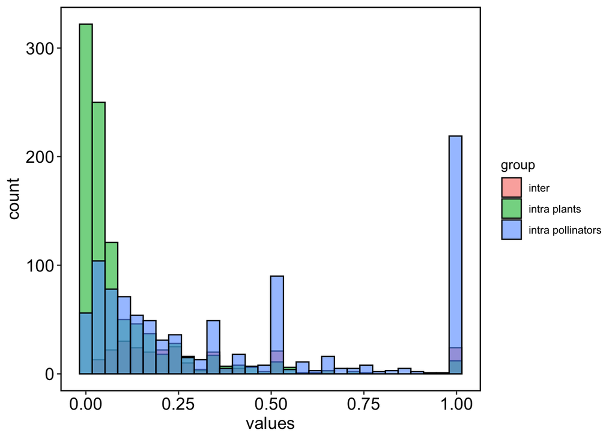

### 3.2.3 Realized interedges

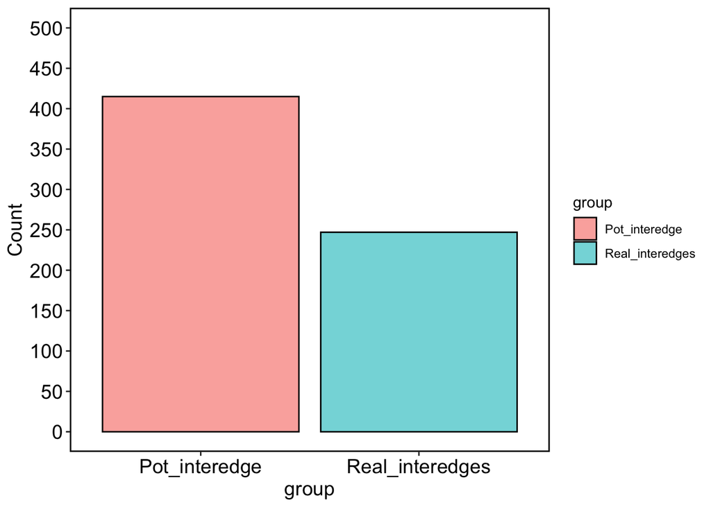

### 3.2.4 Distribution pollinator species across locations

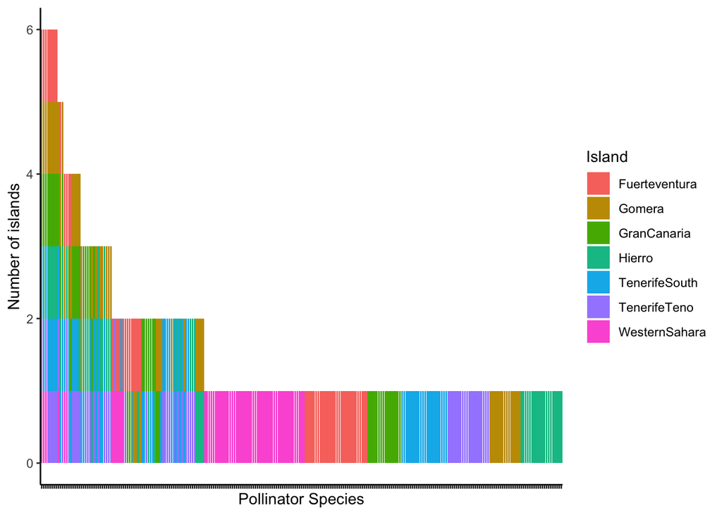

### 3.2.5 Distribution plant species across locations

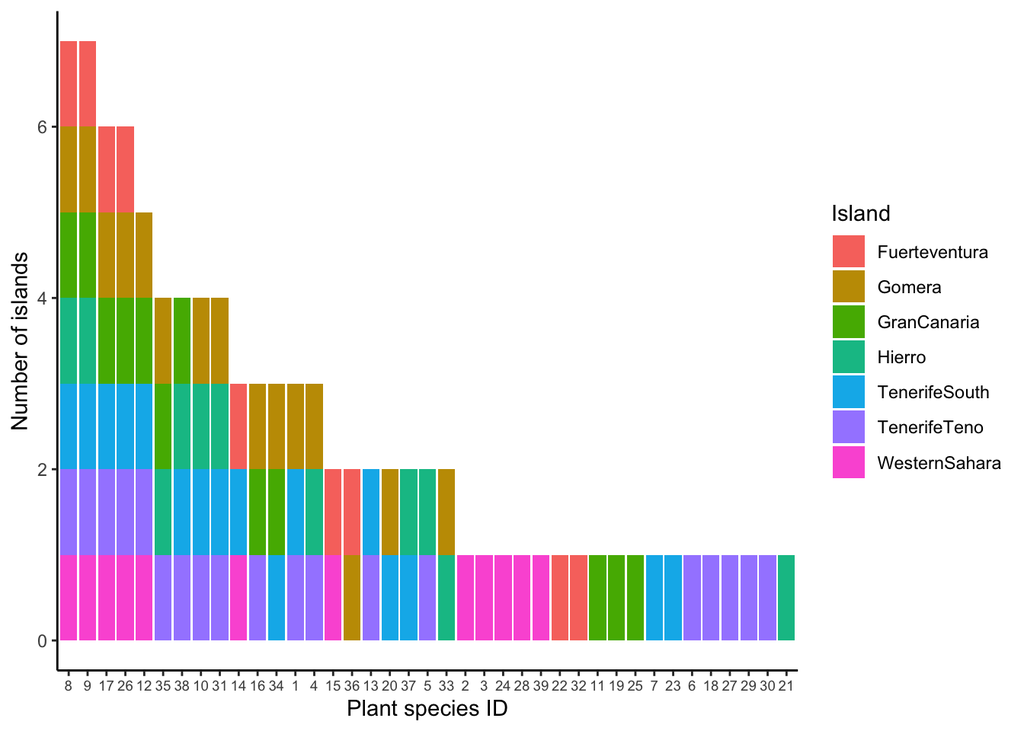

### 3.2.6 Prop. sps of each island that integrate each module

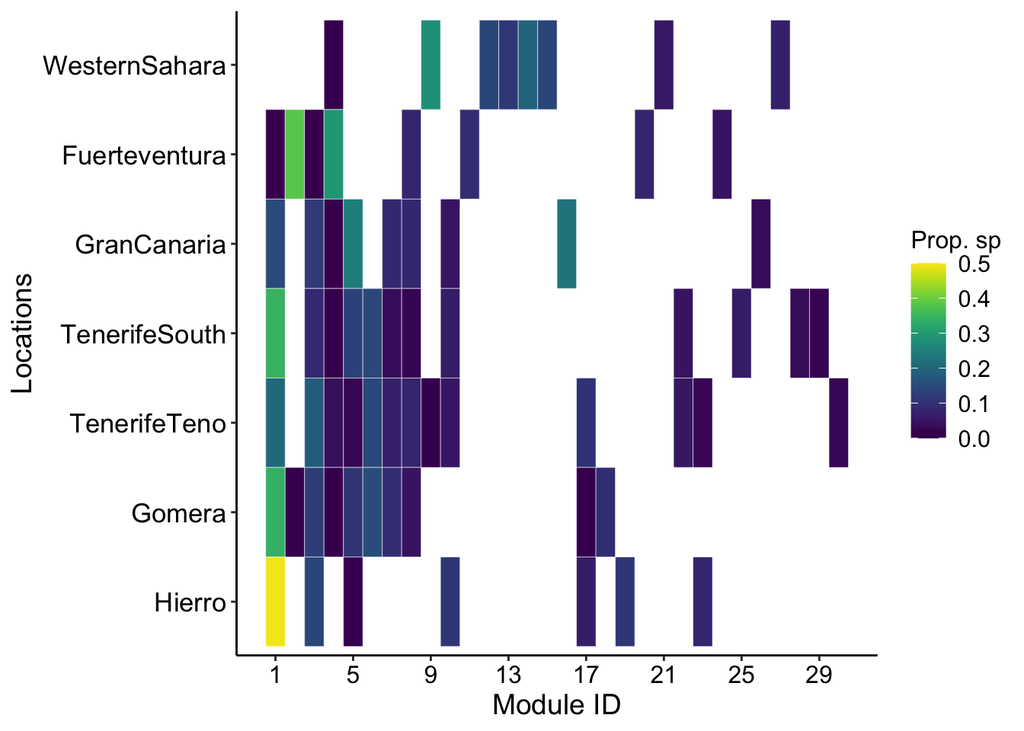

### 3.2.7 Number of modules integrated by one physical node

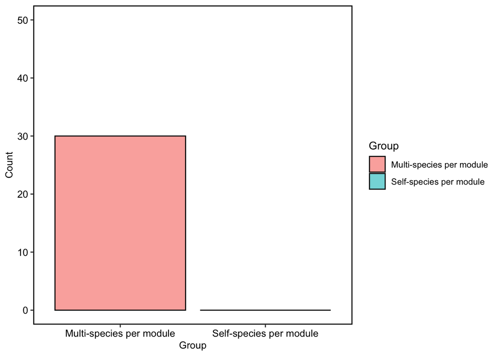

# 4 Results

## 4.1 Distance decay - Empirical

We observed modules distance decay in the empirical data ($R^2$ = 0.538, P < 0.001), which indicates that islands tended to share less modules with increasing distance.

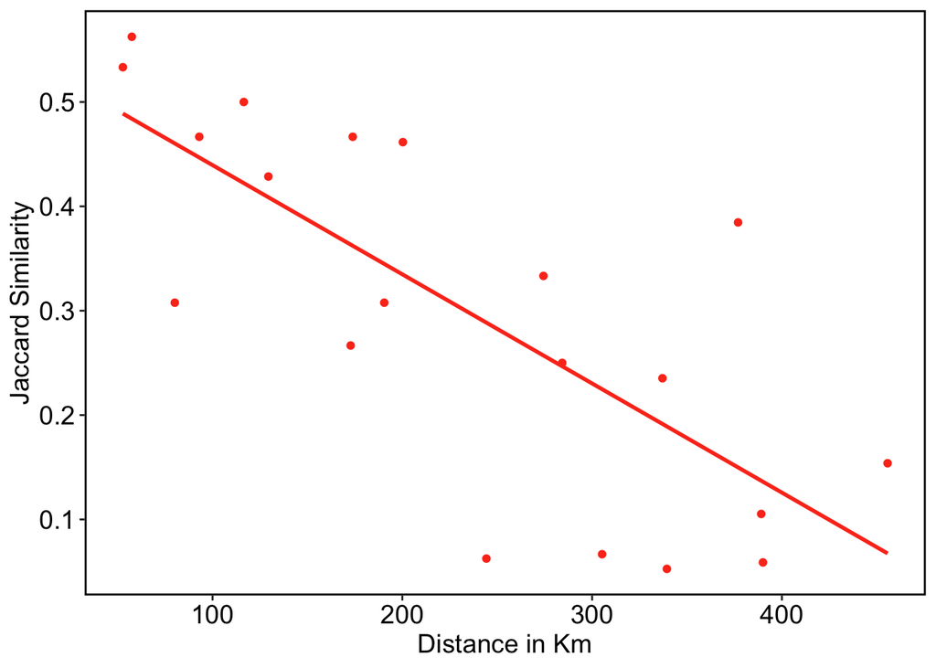

## 4.2 Structure distande decay - Species turnover

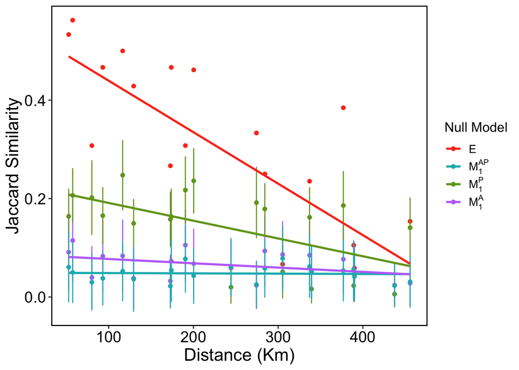

Similarly, the amount of structure variation explained by distance between locations was lower when we shuffled pollinators and both plants and pollinators than in the empirical network (P < 0.001). Altogether, these results indicate that the spatial distribution of pollinator species contribute to the distance decay pattern found in the empirical network.

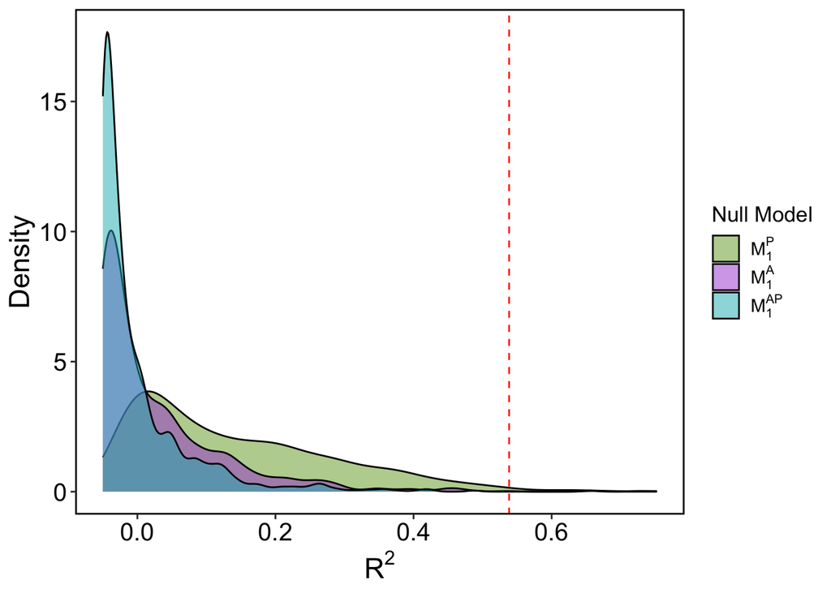

| Model | Intercept | Slope | R² | p - value | df |
| --- | --- | --- | --- | --- | --- |
| E | 0.544 | -0.00100 | 0.538 | <0.001 | 19 |
| M1P | 0.227 | -0.00030 | 0.319 | 4.0000000000000001E-3 | 19 |
| M1A | 0.086 | -0.00009 | 0.123 | 6.5500000000000003E-2 | 19 |
| M1AP | 0.049 | -0.00001 | 0.002 | 0.83399999999999996 | 19 |

## 4.3 Structure distande decay - Interaction rewiring

Shuffling interactions between locations did not break the distance decay pattern in structure ($R^2_{M_2}$ = 0.766, P < 0.001), suggesting that interaction rewiring does not contribute substantially to the pattern found.

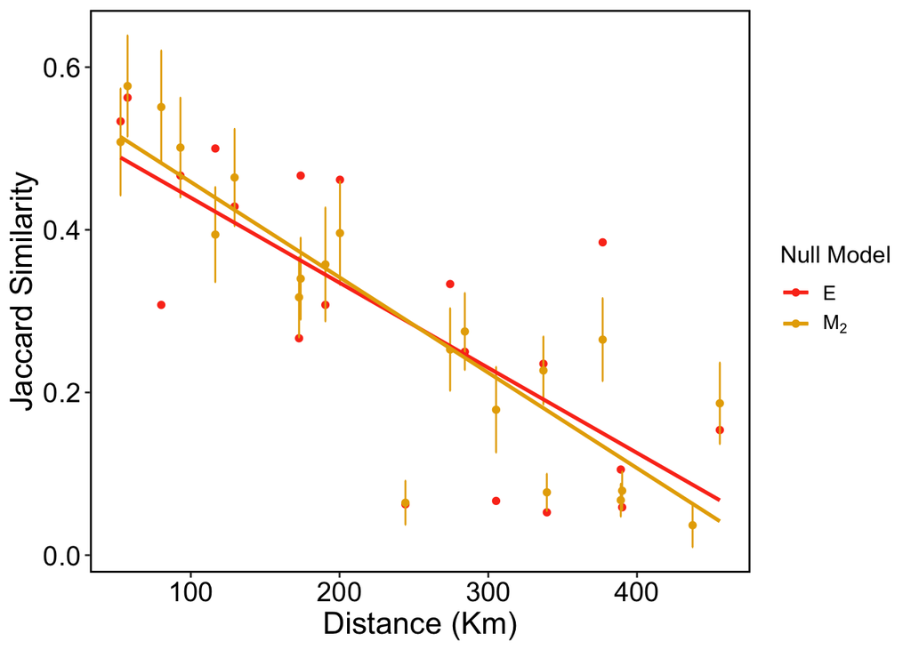

Similarly, it did not affect the overall structure variation explained by distance (P = 0.066)

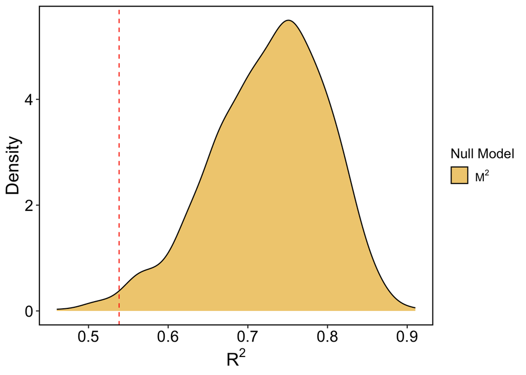

| Model | Intercept | Slope | R² | p - value | df |
| --- | --- | --- | --- | --- | --- |
| E | 0.544 | -0.0010 | 0.538 | <0.001 | 19 |
| M2 | 0.576 | -0.0011 | 0.766 | <0.001 | 19 |

## 4.4 Structure distande decay - Local Factors

Shuffling interactions within locations did not break the distance decay pattern in structure ($R^2_{M_3}$ = 0.60, P < 0.001), suggesting that local factors does not contribute substantially to the pattern found.

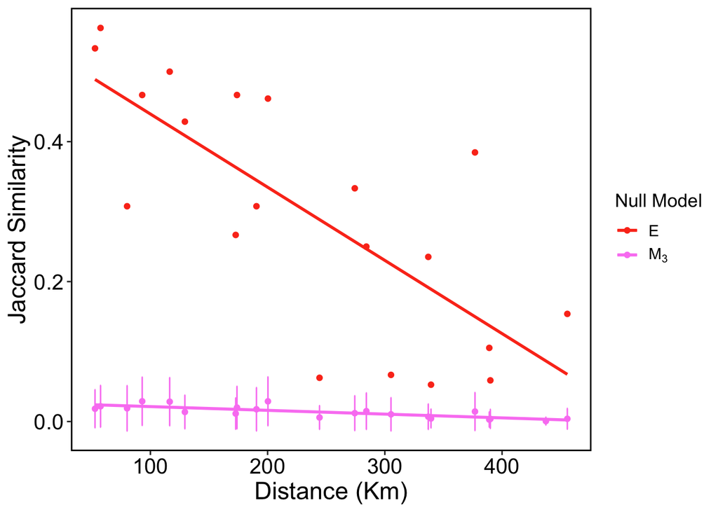

However, it had a significant effect on the overall structure variation explained by distance (P < 0.005) and reduced the magnitude of the effect of distance decay in structure (Slope$_{M_3}$ = -0.000053 vs. Slope$_{Empirical}$ = -0.001).

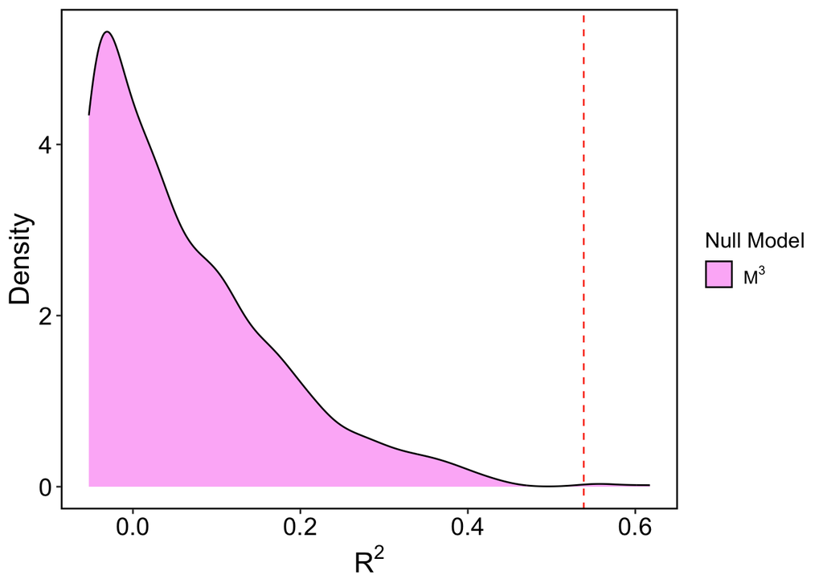

| Model | Intercept | Slope | R² | p - value | df |
| --- | --- | --- | --- | --- | --- |
| E | 0.544 | -0.00100 | 0.538 | <0.001 | 19 |
| M3 | 0.026 | -0.00005 | 0.600 | <0.001 | 19 |

## 4.5 Structure distance decay - Changes in partner similarity

In addition, modifying partner similarity of species across locations ($M_4$) produces a similar pattern of distance decay in modules as the empirical network, suggesting that partner fidelity is not an important driver of distance decay in structure.

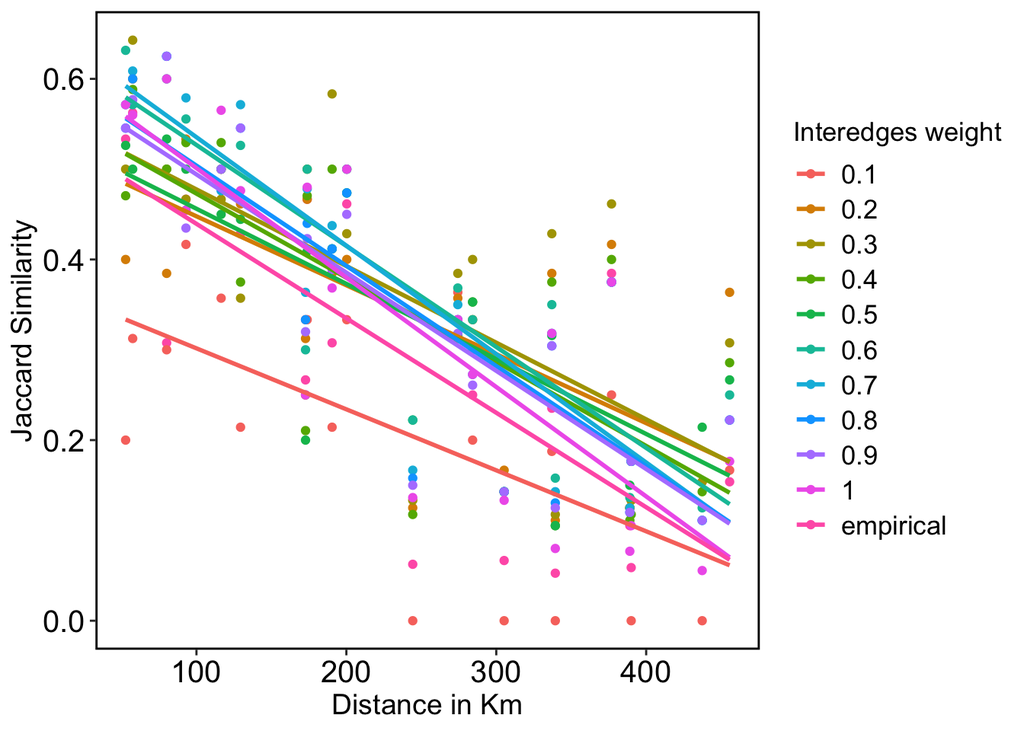